# Klasse-B slides

Klasse B versterkers

Laagfrequent versterkers  
met 2 vermogentransistor

Jan Genoe

Februari 2026

###### Situering

- Invoering van symmetrie
  - 2 transistors die elk de helft van de tijd in geleiding zijn
  - DC werkingspunt in een zone van geringe dissipatie
    - geen stroom door beide transistors
- Benamingen
  - balansschakeling
  - push-pull (duw-trek)
- Complexere schema’s in vergelijking met klasse A, maar een hoger rendement
  - duurder in fabricatie
  - goedkoper in werking

###### Basis schema

## Basisschema

###### Basisschema

[figure not shown]

- NPN en PNP type transistor zijn beide de helft van de tijd in geleiding (bij sinusvormige sturing)
- Ook voor DC toepassingen bruikbaar

###### Pull-up en Pull Down

[figure not shown]

###### Benoeming knopen

[figure not shown]

###### SPICE code

```
Klasse B versterker
*
* SUPPLY VOLTAGES
VPOS 8 0 DC	+15V
VNEG 9 0 DC	-15V
*
*  input source
VS1 1 0	DC 0 SIN(0V 5VPEAK 10KHZ)
*
*  PUSH-PULL TRANSISTOR OUTPUT STAGE
Q1 8 1 2 QNPN
Q2 9 1 2 QPNP
*
* Load resistance
RL1 2 0	100
*
* DEVICE MODELS
.model QNPN	NPN(BF=50)
.model QPNP	PNP(BF=50)
```

###### Verloop van Stroom en Spanning

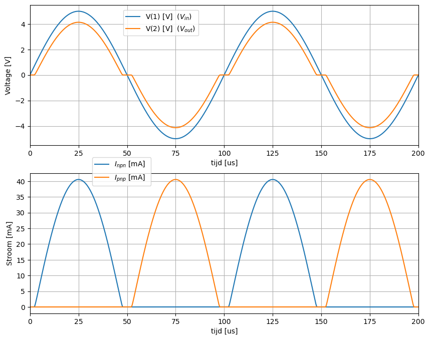

###### Detail stroom en spanning rond nuldoorgang

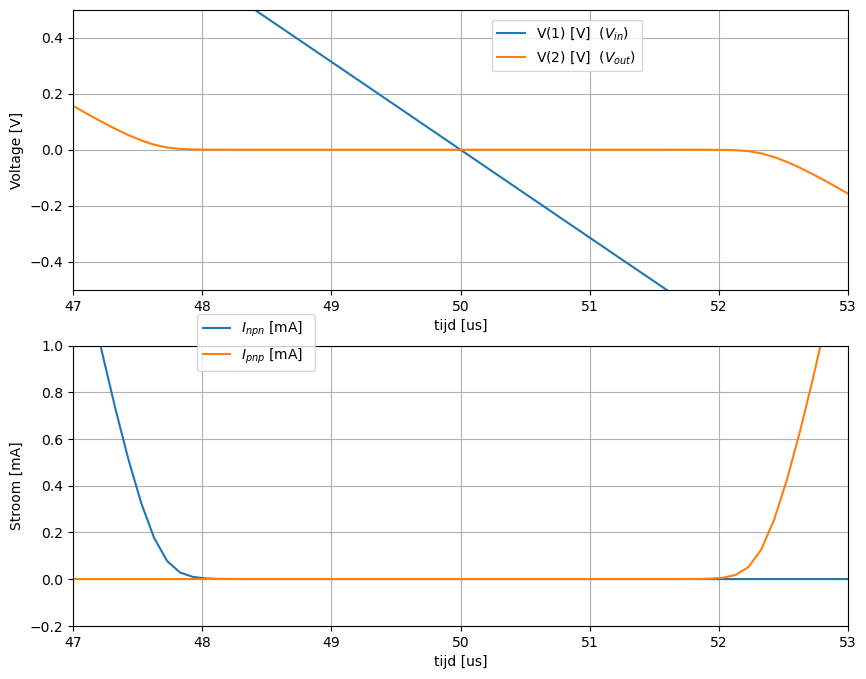

###### Stroom door en spanning over

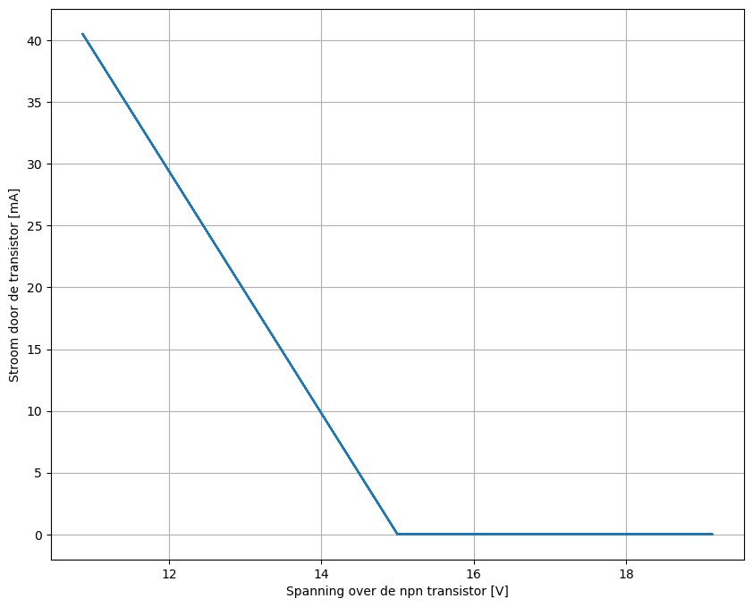

###### AC schema

[figure not shown]

- Geen aftakkingen op de voeding nodig
  - Goedkopere voeding
- Geen gevaar voor drift
  - In de DC versie geeft drift van het instelpunt belangrijke DC stromen door de belasting.

###### Transistor instelling

[figure not shown]

- Basissen worden gezamenlijk gestuurd met dezelfde spanning
- Beide transistors zijn emitter volgers
  - spanningsversterking = 1
  - stroomversterking $\beta$

###### Cross-over en distorsie

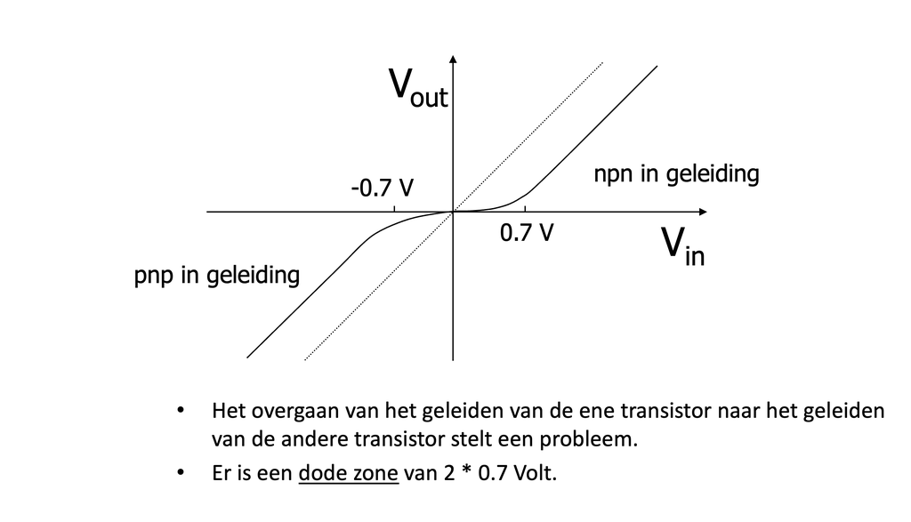

###### Gebruik van de voorinstelspanning

## Gebruik van de voorinstelspanning

###### Voorinstelspanning

[figure not shown]

###### Spanningsdeler als instelspanning

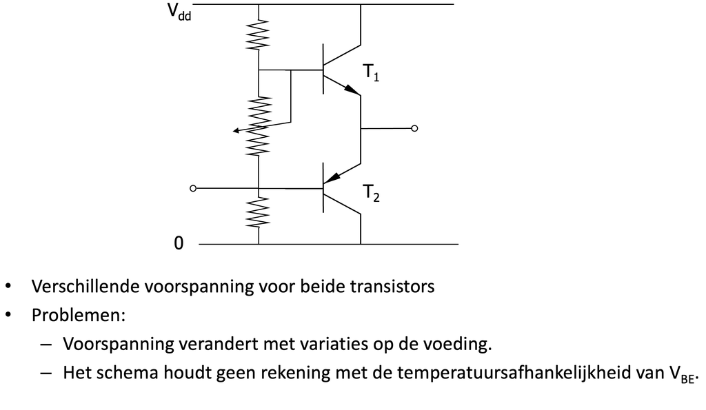

###### Diodes als instelelement

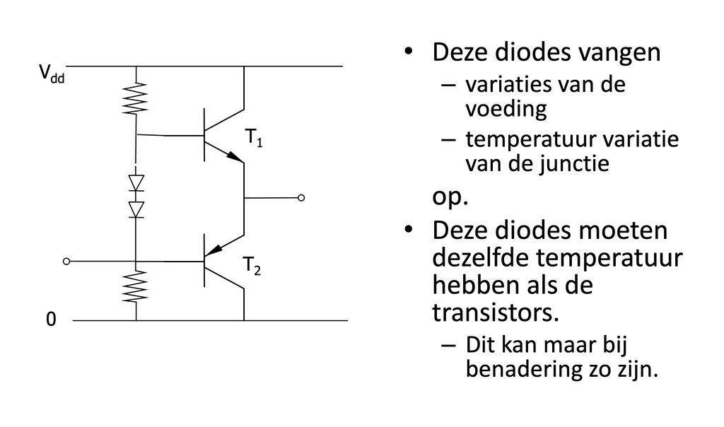

###### Diodes als instelelement

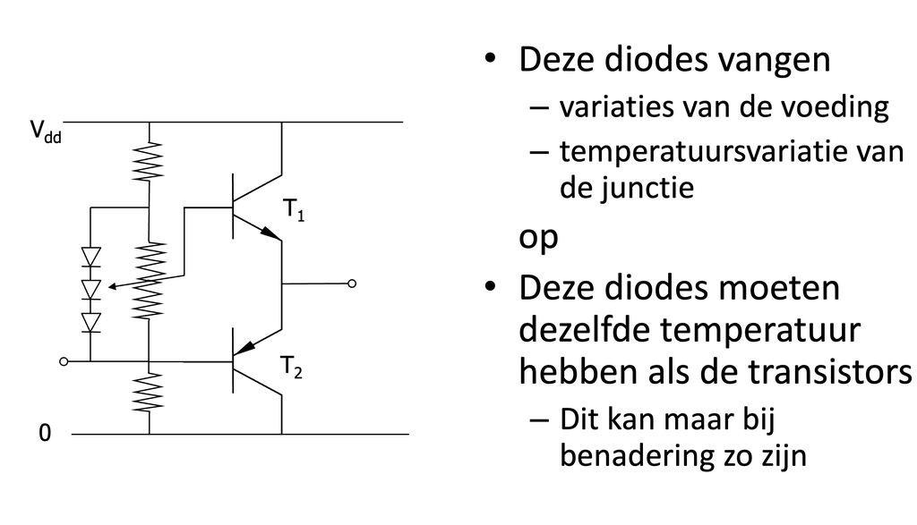

###### Voorinstelspanning met diodes

[figure not shown]

###### SPICE code: voorinstelspanning met diodes

```
Klasse B versterker
*
* SUPPLY VOLTAGES
VPOS 8 0 DC +15V
VNEG 9 0 DC -15V
*
VS2 10 0 DC 0 SIN(0V 5VPEAK 10KHZ)
*
D1  13 10   DNOM
RB1 13 8    10K
Q11 8 13 12 QNPN
*
D2  10 14   DNOM
RB2 14 9    10K
Q12 9 14 12 QPNP
*
RL2 12 0 100
*
* DEVICE MODELS
.model QNPN NPN(BF=50)
.model QPNP PNP(BF=50)
.model DNOM D()
```

###### Stromen en spanning (met voorinstelspanning)

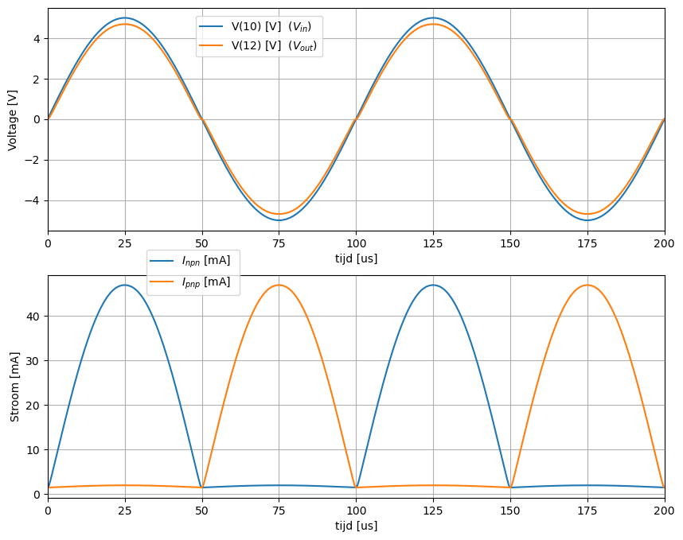

###### Stroom door en spanning over (met voorinstelspanning)

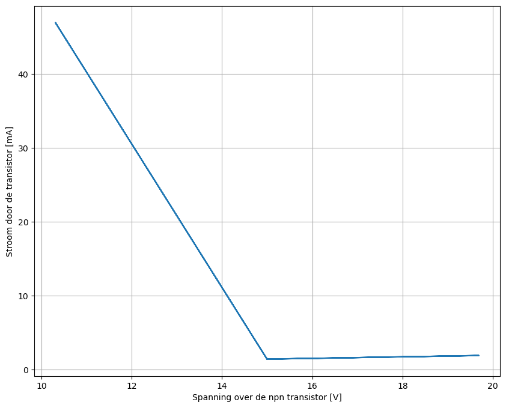

###### Voorinstelspanning met transistor

[figure not shown]

###### Hulptransistor als instelelement

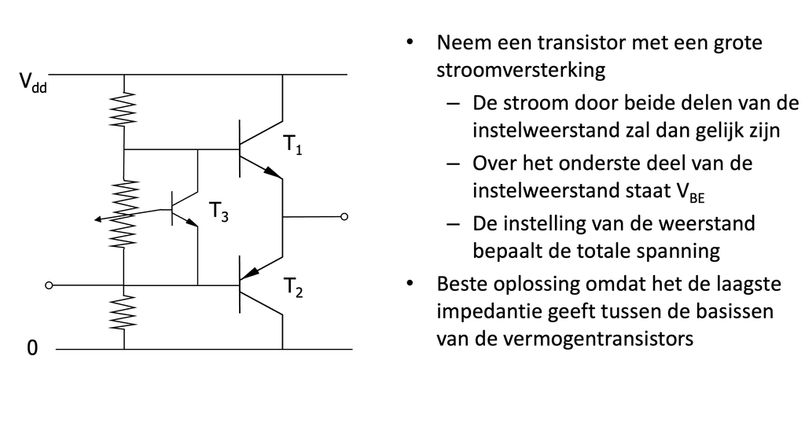

###### Eisen voor de voorspanning

- De voorspanning mag nooit te groot worden.
  - Een te grote voorspanning brengt beide transistors gelijktijdig in geleiding, zodat de voeding kortgesloten wordt.
- De voorspanning mag kleiner worden maar als het signaal door 0 gaat moet ze de ingestelde waarde hebben
- Het optimale gedrag voor de voorspanning is dus een spanningsbron met een lage impedantie

###### Principe van emitter degeneratie

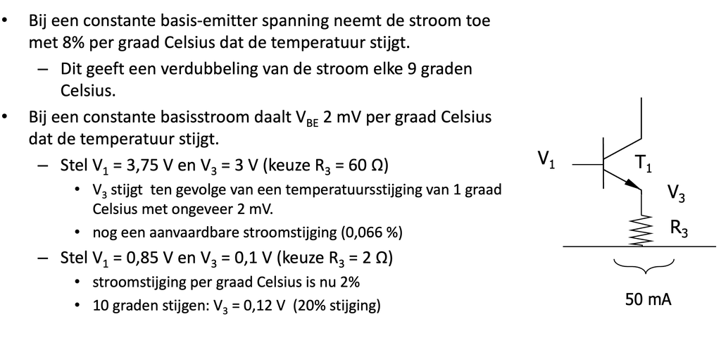

###### Emitter degeneratie

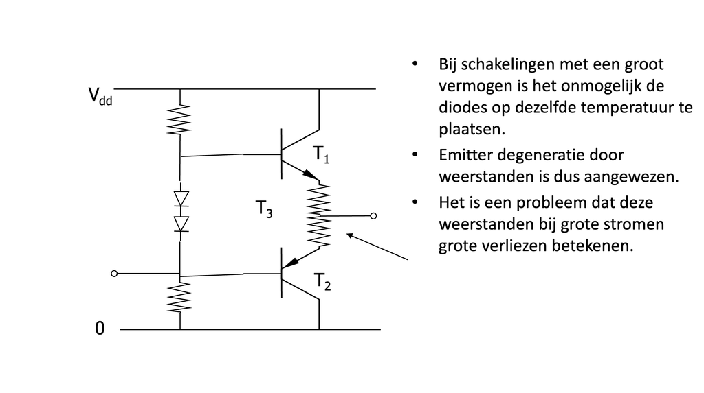

###### Emitter degeneratie

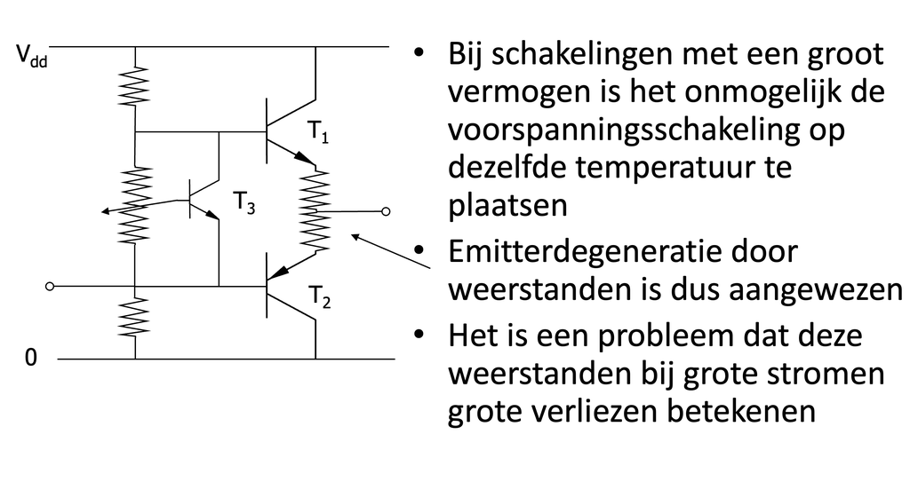

###### Overbruggingsdiodes

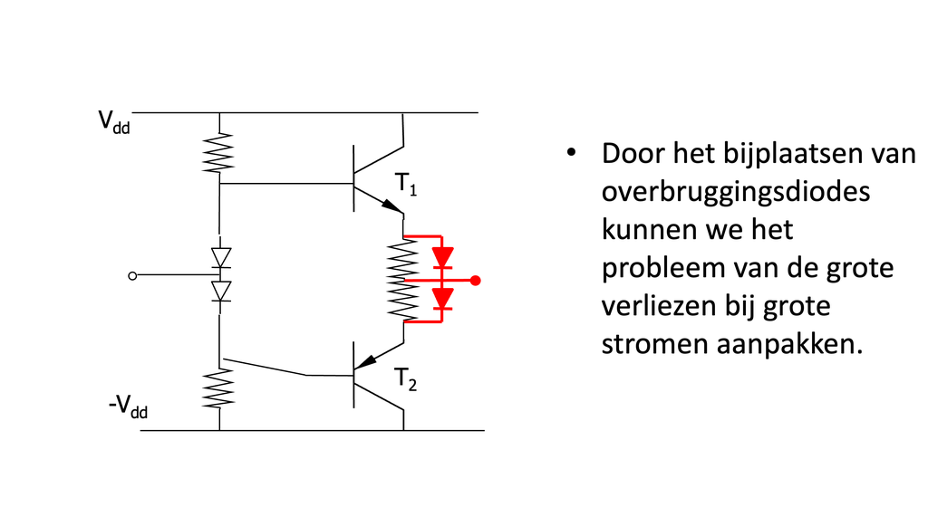

###### Overbruggingsdiodes

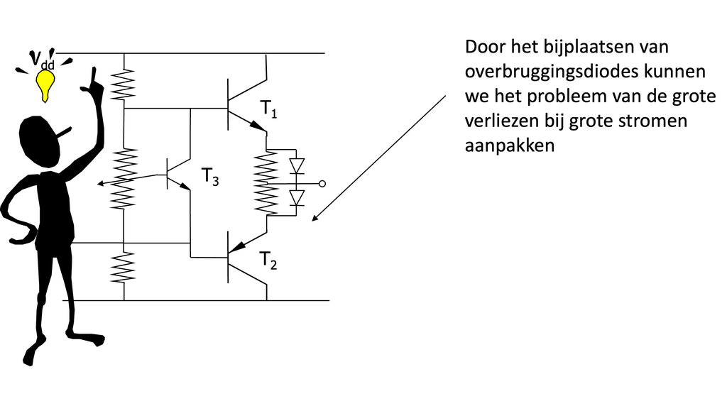

###### Luie zone

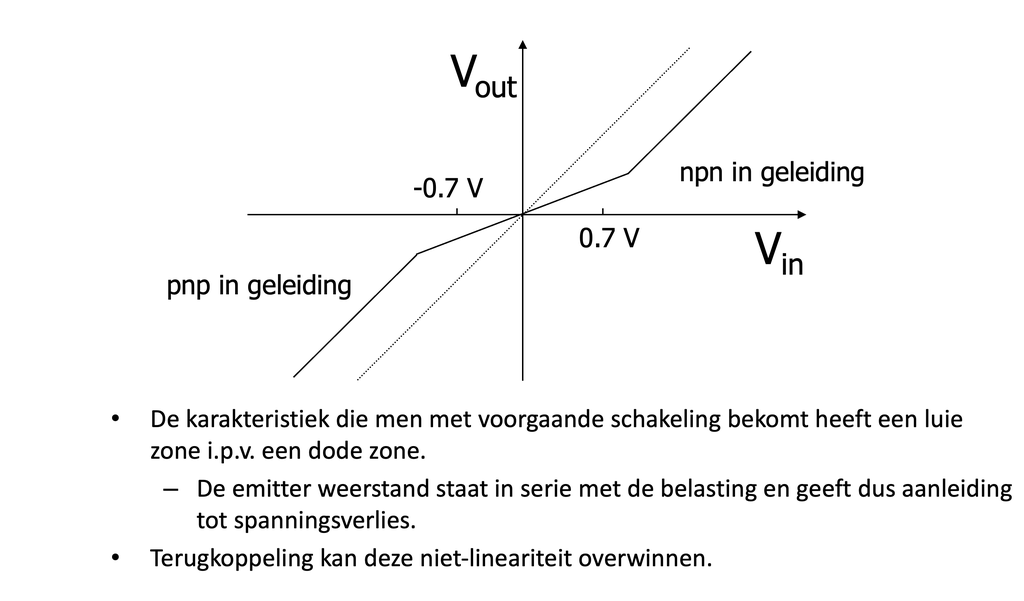

###### Actieve diodes = transistors

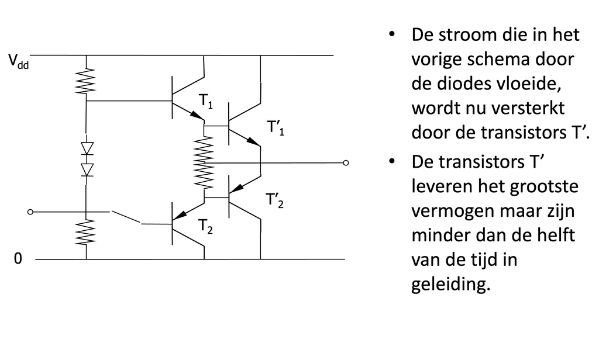

###### Actieve diodes = transistors

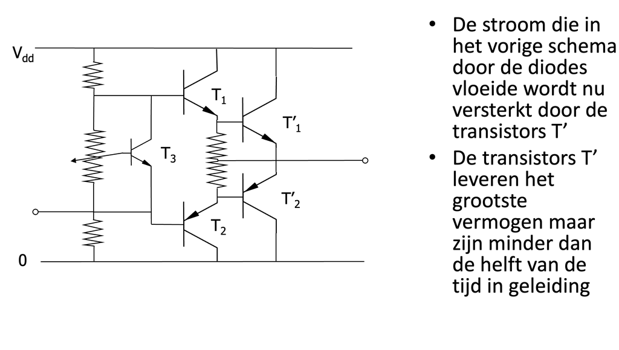

###### Driver stage

## Driver stage

###### Stuurtrap (driver)

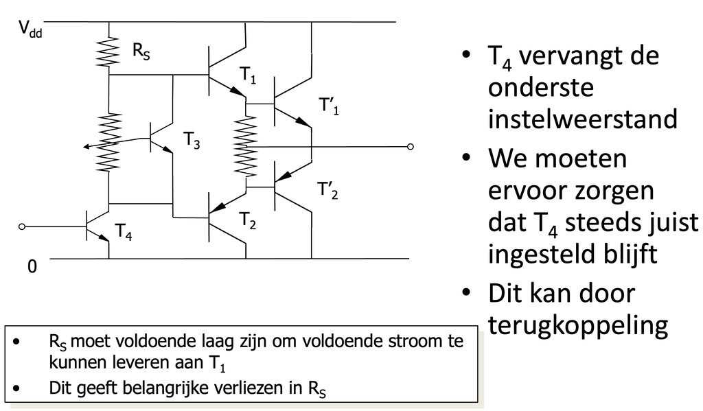

###### Driver Stage

[figure not shown]

###### Stroombron als belasting voor de driver

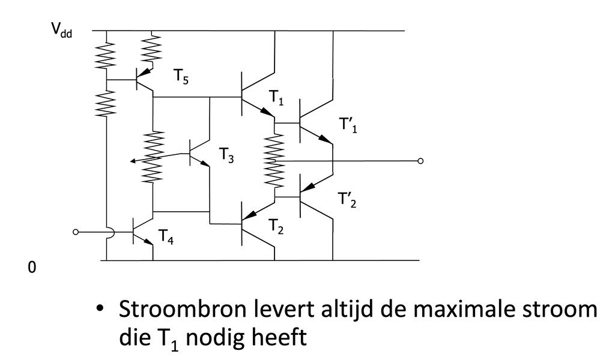

###### Stroombron als belasting driver trap

[figure not shown]

###### Verhoging van het afgeleverde vermogen

## Verhoging van het afgeleverde vermogen

###### Darlington Paar

[figure not shown]

###### SPICE code

```
Darlington
*
*  PUSH-PULL TRANSISTOR OUTPUT STAGE
Q1 3 1 2 QNPN
Q2 3 2 0 QNPN
*
* DEVICE MODELS
.model QNPN	NPN(BF=50)
```

###### Transfer characteristiek Darlington paar

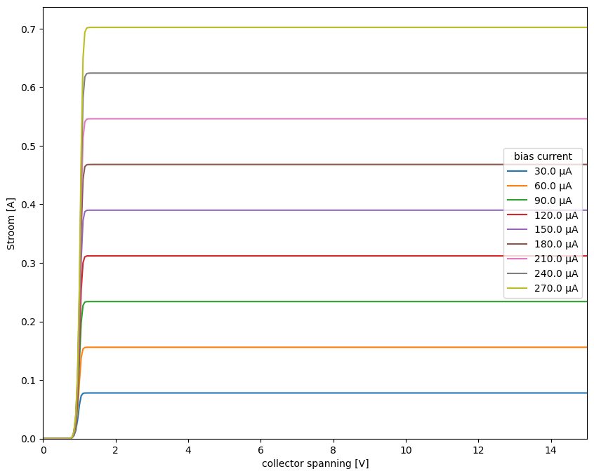

###### Darlington Paar met emitter degeneratie

[figure not shown]

###### SPICE code

```
Darlington met emitter degeneratie
*
*  PUSH-PULL TRANSISTOR OUTPUT STAGE
Q1 3 1 2 QNPN
Q2 3 2 0 QNPN
RED 2 0 100
*
* DEVICE MODELS
.model QNPN	NPN(BF=50)
```

###### Transfer characteristiek Darlington paar

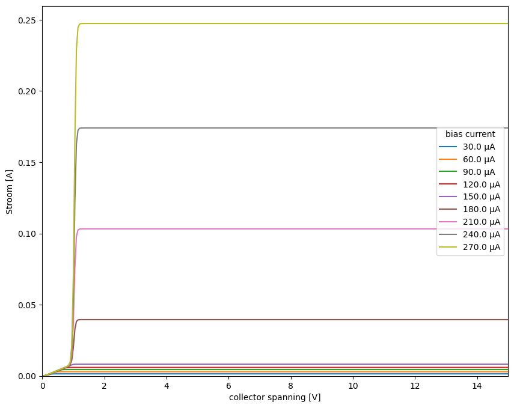

###### Darlington Paar als drive transistors

[figure not shown]

###### Darlington Paar als drive transistors

[figure not shown]

###### Complementair Darlington paar

[figure not shown]

###### SPICE code complementair Darlington paar

```
Complementaire Darlington met emitter degeneratie
*
*  PUSH-PULL TRANSISTOR OUTPUT STAGE
Q1 2 1 0 QNPN
Q2 0 2 3 QPNP
*
* DEVICE MODELS
.model QNPN	NPN(BF=50)
.model QPNP	PNP(BF=50)
```

###### Transfer characteristiek complementair Darlington paar

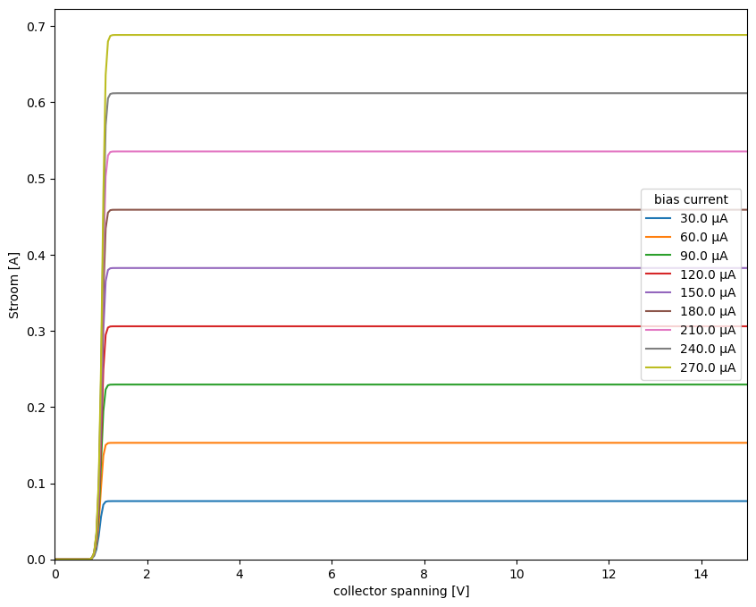

###### Complementair Darlington paar met emitter degeneratie

[figure not shown]

###### SPICE code complementair Darlington paar met emitter degeneratie

```
Complementaire Darlington met emitter degeneratie
*
*  PUSH-PULL TRANSISTOR OUTPUT STAGE
Q1 2 1 4 QNPN
Q2 0 2 3 QPNP
RED 4 0 100
R2 2 3 100
*
* DEVICE MODELS
.model QNPN	NPN(BF=50)
.model QPNP	PNP(BF=50)
```

###### Transfer characteristiek complementair Darlington paar met emitter degeneratie

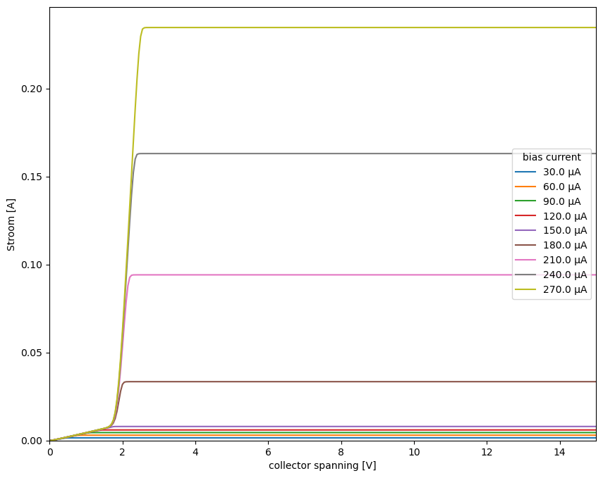

###### PNP vermogentransistors

PNP vermogentransistors zijn

- minder goed,
- minder robust,
- minder betrouwbaar,
- of duurder

dan de vergelijkbare NPN component.

- We vervangen de grootste PNP transistors door NPN transistors.
- T’2 verhuist daardoor van plaats en we moeten de diode terug invoeren.
- We zijn een belangrijk deel van de symmetrie terug kwijt.

###### Schema met NPN eindtrap

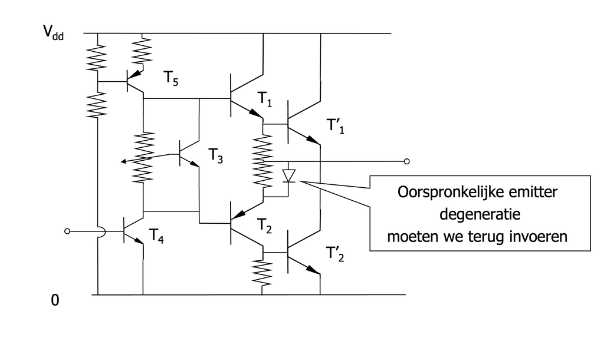

###### Bijkomende trap met invoering symmetrie

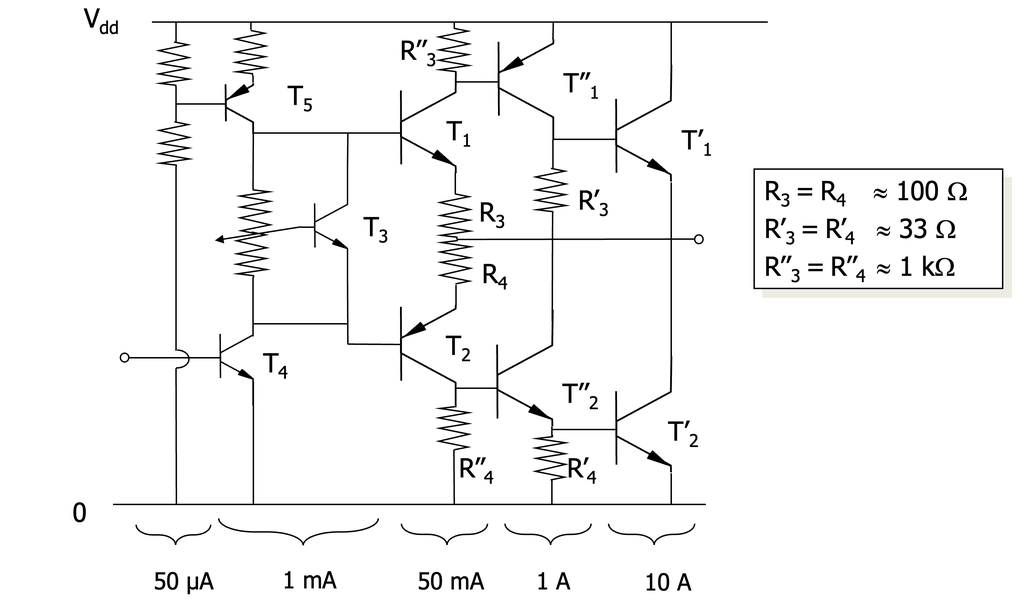

De theoretische berekening van de efficiëntie als functie van de uitsturing benaderen we in eerste instantie door enkel de stroom van het pull-up netwerk en het pull down netwerk te bekijken.

$$\mu=\frac{P_{out}}{P_{in}}=\frac{P_{ac}}{P_{DC}}$$

met de uitsturing (x) gedefinieerd als $\frac{V_{ac}}{V_{DD}}$.

###### Dissipatie en rendement

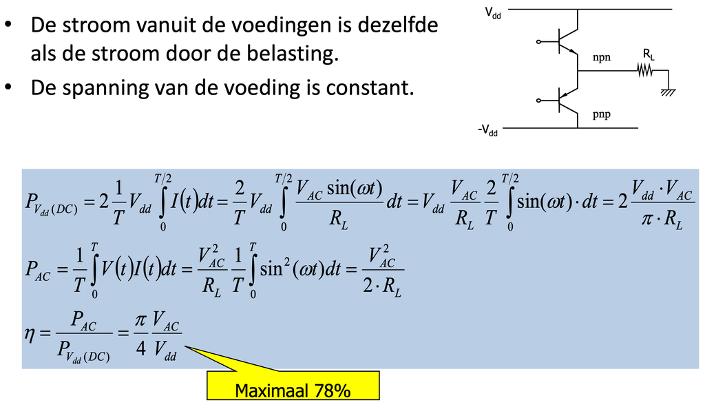

###### Vergelijking rendement

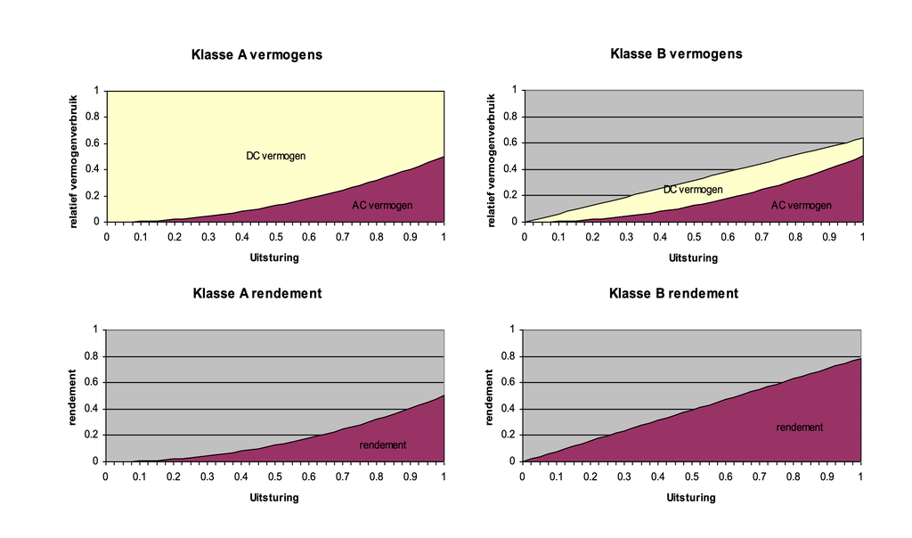

###### Invoering van terugkoppeling

## Invoering van terugkoppeling

###### Vermogentrap zonder terugkoppeling

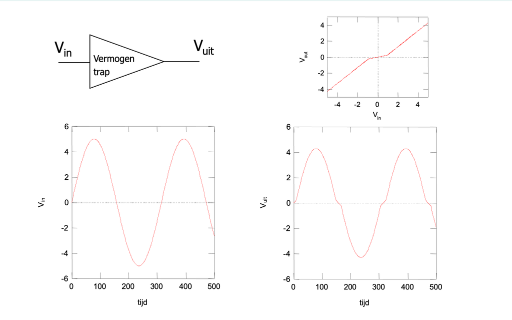

###### Vermogentrap met terugkoppeling

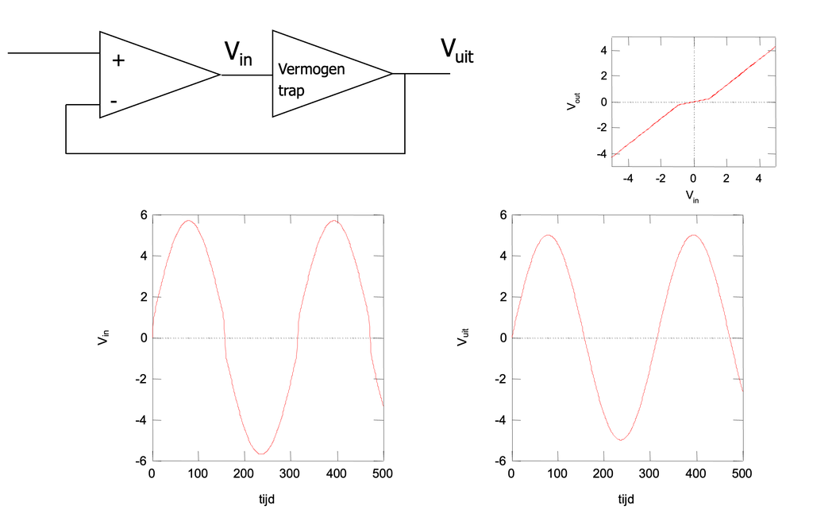

###### SPICE code: 5V input swing

```
Klasse B versterker met OPAMP terugkoppeling
VPOS 8 0 DC +15V
VNEG 9 0 DC -15V
VS3 20 0 DC 0 SIN(0V 5VPEAK 10KHZ)
Q21 8 23 22 QNPN
Q22 9 23 22 QPNP
RL3 22 0 100
XOpAmp 20 22 8 9 23 8 opamp
* DEVICE MODELS
.model QNPN NPN(BF=50)
.model QPNP PNP(BF=50)
.model DNOM D()
```

###### Terugkoppeling: stromen en spanningen

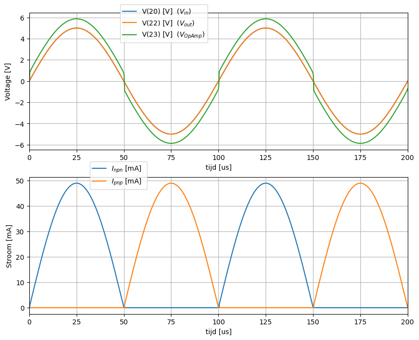